# Practical ML

# Data preparation

```r
library(ggplot2)
library(caret)
library(parallel)
library(doParallel)
library(tictoc)
no_cores <- detectCores() - 1
set.seed(1234)
tic()
```

## Reading data and creating training and testing sets

```r
pml <- read.csv('pml-training.csv')
quizz_testing <- read.csv('pml-testing.csv')

train_sample = sample(1:dim(pml)[1],size=dim(pml)[1]*0.7,replace=F)
training = pml[train_sample,]
testing = pml[-train_sample,]
training$classe <- as.factor(training$classe)
```

The dataset “quizz_testing” doesn’t contain column “classe”, but contains another column named “problem_id” which will be used for the last quizz of the course.

## Managing NA values (removing some columns)

```r
count_na_training <- data.frame(cols=colnames(training), count=as.factor(apply(training, 2, function(x) sum(is.na(x)))))

table(count_na_training$count)
```

```
##
##     0 13432
##    93    67
```

67 columns have NA values on 13432 rows. Let’s confirm the 13432 NA values are the same for all columns (looks obvious, but it’s better to ensure). I create a subset of training, named NA_training containing only rows with NA values in one column (max_roll_belt). Then, I apply again the same count on NA values. The result is the same as on the global training data set : 67 columns have 13432 NA rows. So this is the confirmation that 13432 rows have NA values, and other rows are complete.

```r
NA_training <- training[is.na(training$max_roll_belt),]

count_na_training2 <- data.frame(cols=colnames(NA_training), count=as.factor(apply(NA_training, 2, function(x) sum(is.na(x)))))

summary(count_na_training2)
```

```
##            cols       count
##  accel_arm_x :  1   0    :93
##  accel_arm_y :  1   13432:67
##  accel_arm_z :  1
##  accel_belt_x:  1
##  accel_belt_y:  1
##  accel_belt_z:  1
##  (Other)     :154
```

If we remove all NA rows, we’ll have too few remaining training data. I’ll remove NA columns from the dataset instead. First, I check the columns with NA in testing dataset.

```r
count_na_testing <- data.frame(cols=colnames(testing), count=as.factor(apply(testing, 2, function(x) sum(is.na(x)))))

summary(count_na_testing)
```

```
##            cols      count
##  accel_arm_x :  1   0   :93
##  accel_arm_y :  1   5784:67
##  accel_arm_z :  1
##  accel_belt_x:  1
##  accel_belt_y:  1
##  accel_belt_z:  1
##  (Other)     :154
```

Then I remove columns from both datasets. I also remove unsused columns and columns containing “DIV/0” values.

```r
training2 <- training[,count_na_testing$count==0 & count_na_training$count==0]
testing2  <- testing[,count_na_testing$count==0 & count_na_training$count==0]

#removing unused variables
training2 <- training2[,-c(1:7)]
testing2 <- testing2[,-c(1:7)]

training2 <- training2[, -grep("kurtosis_.", colnames(training2))]
training2 <- training2[, -grep("skewness_.", colnames(training2))]
training2 <- training2[, -grep("max_.", colnames(training2))]
training2 <- training2[, -grep("min_.", colnames(training2))]
training2 <- training2[, -grep("amplitude_.", colnames(training2))]

testing2 <- testing2[, -grep("kurtosis_.", colnames(testing2))]
testing2 <- testing2[, -grep("skewness_.", colnames(testing2))]
testing2 <- testing2[, -grep("max_.", colnames(testing2))]
testing2 <- testing2[, -grep("min_.", colnames(testing2))]
testing2 <- testing2[, -grep("amplitude_.", colnames(testing2))]
```

# Train models

I will run 4 different models : - Random forest - Tree (rpart) - Bossting - Bagging

Then, I will combine these models to try to get the best accuracy of each.

```r
fitControl <- trainControl(method = "cv", number = 6, allowParallel = TRUE)
```

## Random forest

```r
cluster <- makeCluster(detectCores() - 1)
registerDoParallel(cluster)

tic()
fit_rf <- train(classe~., data=training2, method="rf", trControl=fitControl)
toc()
```

```
## 269.61 sec elapsed
```

```r
stopCluster(cluster)
registerDoSEQ()

fit_rf
```

```
## Random Forest
##
## 13735 samples
##    52 predictor
##     5 classes: 'A', 'B', 'C', 'D', 'E'
##
## No pre-processing
## Resampling: Cross-Validated (6 fold)
## Summary of sample sizes: 11446, 11446, 11446, 11445, 11447, 11445, ...
## Resampling results across tuning parameters:
##
##   mtry  Accuracy   Kappa
##    2    0.9917000  0.9895052
##   27    0.9914813  0.9892296
##   52    0.9844916  0.9803910
##
## Accuracy was used to select the optimal model using the largest value.
## The final value used for the model was mtry = 2.
```

Accuracy looks very good.

## Tree

```r
cluster <- makeCluster(detectCores() - 1)
registerDoParallel(cluster)
fitGrid_rpart <- expand.grid(cp=c(0.001, 0.0006, 0.0001, 0.00006))

tic()
fit_rpart <- train(classe~., data=training2, method="rpart", trControl=fitControl, tuneGrid=fitGrid_rpart)
toc()
```

```
## 28.04 sec elapsed
```

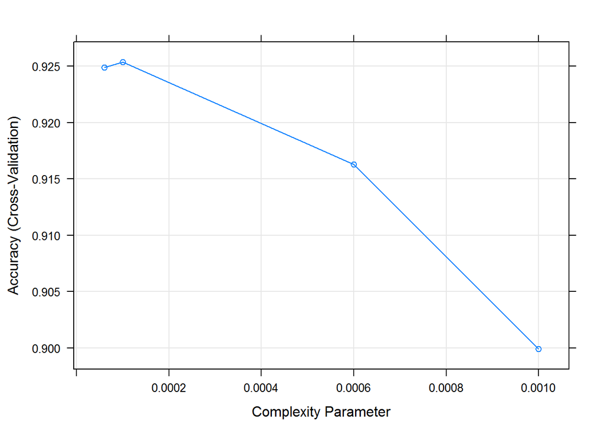

```r
stopCluster(cluster)
registerDoSEQ()

plot(fit_rpart)
```

## Bagging

```r
cluster <- makeCluster(detectCores() - 1)
registerDoParallel(cluster)

tic()
fit_treebag <- train(classe~., data=training2, method="treebag", trControl=fitControl)
toc()
```

```
## 58.67 sec elapsed
```

```r
stopCluster(cluster)
registerDoSEQ()

fit_treebag
```

```
## Bagged CART
##
## 13735 samples
##    52 predictor
##     5 classes: 'A', 'B', 'C', 'D', 'E'
##
## No pre-processing
## Resampling: Cross-Validated (6 fold)
## Summary of sample sizes: 11447, 11446, 11445, 11445, 11447, 11445, ...
## Resampling results:
##
##   Accuracy   Kappa
##   0.9832547  0.9788273
```

## Boosting

```r
cluster <- makeCluster(detectCores() - 1)
registerDoParallel(cluster)

tic()
fit_gbm <- train(classe~., data=training2, method="gbm", trControl=fitControl)
toc()
```

```
## 150.89 sec elapsed
```

```r
stopCluster(cluster)
registerDoSEQ()
```

# Cross-Validation

For cross validation, I will use my testing2 dataset, and predict result with each model. Then I will combine prediction through a voting formula and calculate the confusionMatrix of this result.

```r
pred_rf <- predict(fit_rf, testing2)
pred_rpart <- predict(fit_rpart, testing2)
pred_gbm <- predict(fit_gbm, testing2)
pred_treebag <- predict(fit_treebag, testing2)

pred_merge <- data.frame(pred_rf, pred_rpart, pred_gbm, pred_treebag, classe=testing2$classe)

pred_merge$nb_A <- (pred_merge$pred_rf=='A') + (pred_merge$pred_rpart=='A') + (pred_merge$pred_gbm=='A') + (pred_merge$pred_treebag=='A')
pred_merge$nb_B <- (pred_merge$pred_rf=='B') + (pred_merge$pred_rpart=='B') + (pred_merge$pred_gbm=='B') + (pred_merge$pred_treebag=='B')
pred_merge$nb_C <- (pred_merge$pred_rf=='C') + (pred_merge$pred_rpart=='C') + (pred_merge$pred_gbm=='C') + (pred_merge$pred_treebag=='C')
pred_merge$nb_D <- (pred_merge$pred_rf=='D') + (pred_merge$pred_rpart=='D') + (pred_merge$pred_gbm=='D') + (pred_merge$pred_treebag=='D')
pred_merge$nb_E <- (pred_merge$pred_rf=='E') + (pred_merge$pred_rpart=='E') + (pred_merge$pred_gbm=='E') + (pred_merge$pred_treebag=='E')

pred_merge$vote <-
    ifelse(pred_merge$nb_A>2,'A',
           ifelse(pred_merge$nb_B>2,'B',
                  ifelse(pred_merge$nb_C>2,'C',
                         ifelse(pred_merge$nb_D>2,'D',
                                ifelse(pred_merge$nb_E>2,'E',
                                       ifelse(pred_merge$nb_A==2,'A',
                                              ifelse(pred_merge$nb_B==2,'B',
                                                     ifelse(pred_merge$nb_C==2,'C',
                                                            ifelse(pred_merge$nb_D==2,'D','E')))))))))

confusionMatrix(pred_merge$vote, pred_merge$classe)
```

```
## Confusion Matrix and Statistics
##
##           Reference
## Prediction    A    B    C    D    E
##          A 1712   20    1    1    0
##          B    2 1052   19    4    5
##          C    1    3  992   20    3
##          D    1    0   10  966    7
##          E    0    1    1    0 1066
##
## Overall Statistics
##
##                Accuracy : 0.9832
##                  95% CI : (0.9796, 0.9863)
##     No Information Rate : 0.2915
##     P-Value [Acc > NIR] : < 2.2e-16
##
##                   Kappa : 0.9787
##  Mcnemar's Test P-Value : NA
##
## Statistics by Class:
##
##                      Class: A Class: B Class: C Class: D Class: E
## Sensitivity            0.9977   0.9777   0.9697   0.9748   0.9861
## Specificity            0.9947   0.9938   0.9944   0.9963   0.9996
## Pos Pred Value         0.9873   0.9723   0.9735   0.9817   0.9981
## Neg Pred Value         0.9990   0.9950   0.9936   0.9949   0.9969
## Prevalence             0.2915   0.1828   0.1738   0.1683   0.1836
## Detection Rate         0.2908   0.1787   0.1685   0.1641   0.1811
## Detection Prevalence   0.2945   0.1838   0.1731   0.1671   0.1814
## Balanced Accuracy      0.9962   0.9857   0.9821   0.9855   0.9929
```

# Conclusions

```r
acc_rf_tr <- max(fit_rf$results[,'Accuracy'])
acc_rpart_tr <- max(fit_rpart$results[,'Accuracy'])
acc_gbm_tr <- max(fit_gbm$results[,'Accuracy'])
acc_treebag_tr <- max(fit_treebag$results[,'Accuracy'])
acc_combo_tr <- NA
acc_rf_tst <- confusionMatrix(pred_rf, testing2$classe)$overall['Accuracy']
acc_rpart_tst <- confusionMatrix(pred_rpart, testing2$classe)$overall['Accuracy']
acc_gbm_tst <- confusionMatrix(pred_gbm, testing2$classe)$overall['Accuracy']
acc_treebag_tst <- confusionMatrix(pred_gbm, testing2$classe)$overall['Accuracy']
acc_combo_tst <- confusionMatrix(pred_merge$vote, testing2$classe)$overall['Accuracy']

synthesis <- data.frame(training=c(acc_rf_tr, acc_rpart_tr, acc_gbm_tr, acc_treebag_tr, acc_combo_tr))
synthesis$testing <- c(acc_rf_tst, acc_rpart_tst, acc_gbm_tst, acc_treebag_tst, acc_combo_tst)
rownames(synthesis) <- c('Random forest', 'Tree', 'Boosting', 'Bagging', 'Combined')

synthesis
```

```
##                training   testing
## Random forest 0.9917000 0.9916766
## Tree          0.9253725 0.9315441
## Boosting      0.9629413 0.9626295
## Bagging       0.9832547 0.9626295
## Combined             NA 0.9831833
```

I presented here the synthesis of accuracy of all my models, including the crombined model. First think we can see is that we don’t have overfitting issue. If we had such issue, we would see a bad accuracy in testing, while here, the accuracy for testing dataset is close the the accuracy of training dataset.

As we can see, the most performant model is the Random Forest. Combo doesn’t improve the accuracy, so I decided to keep the Random Forest as a final model, with 99% Accuracy.

```r
quizz_result <- predict(fit_rf, quizz_testing)
quizz_result <- data.frame(result = quizz_result)
row.names(quizz_result) <- quizz_testing$problem_id
toc()
```

```
## 40.77 sec elapsed
```